# fertilization-analysis-REDO

Laura H Spencer

2/16/2020

### Load libraries

```r
knitr::opts_chunk$set(echo = TRUE)

list.of.packages <- c("gsheet", "tidyverse", "janitor", "plotly", "glmmTMB", "metafor", "broom.mixed", "car") #add new libraries here

new.packages <- list.of.packages[!(list.of.packages %in% installed.packages()[,"Package"])]
if(length(new.packages)) install.packages(new.packages)

# Load all libraries
lapply(list.of.packages, FUN = function(X) {
  do.call("require", list(X))
})
sessionInfo()
```

### Prepare data

NOTE: data is read directly from the GoogleSheet using a share link that was set to “anyone with a link can view”

```r
# Read in data from GoogleSheet
data.fert <- as_tibble(gsheet2tbl('https://docs.google.com/spreadsheets/d/111SuH548Et6HDckjbQjtYk-B8A5VfNkUYZgcUNRPxxY/edit?usp=sharing'))
#replace NR (not reported) with NA and convert columns to factor / numeric where needed
data.fert <- data.fert %>%
  na_if("NR") %>%
  mutate_at(c('Phylum', 'Study', 'Taxonomic Group', 'Common name', 'Latin name', 'Error statistic'), as.factor) %>%
  mutate_at(c('pH Experimental', 'pH Control', 'pCO2 Experimental', 'pCO2 Control', 'Ave. Fert. % @ pH', 'Error % @ pH', '# Trials @ pH', 'Insemination time'), as.numeric) %>%
  clean_names()  # fill in spaces with underscores for column names
str(data.fert)
```

```
## Classes 'tbl_df', 'tbl' and 'data.frame':    334 obs. of  22 variables:
##  $ phylum                  : Factor w/ 4 levels "Cnidaria","Crustacea",..: 4 4 4 4 4 4 4 4 4 4 ...
##  $ paper_link              : chr  "https://doi.org/10.1016/j.jembe.2012.12.014" "https://doi.org/10.1016/j.jembe.2012.12.014" "https://doi.org/10.1016/j.jembe.2012.12.014" "https://doi.org/10.1080/15287394.2011.550460" ...
##  $ study                   : Factor w/ 37 levels "Albright, 2011",..: 3 3 3 4 4 5 5 6 6 6 ...
##  $ taxonomic_group         : Factor w/ 10 levels "abalone","clam",..: 8 8 8 5 5 8 8 2 2 2 ...
##  $ common_name             : Factor w/ 30 levels "amphipod","Antarctic bivalve",..: 21 21 21 7 7 11 11 2 2 2 ...
##  $ latin_name              : Factor w/ 41 levels "Acartia erythraea",..: 12 12 12 29 29 13 13 23 23 23 ...
##  $ p_h_experimental        : num  7.37 7.76 8.09 7.6 8.1 7.5 7.9 7.63 7.63 7.63 ...
##  $ p_h_control             : num  8.09 8.09 8.09 8.1 8.1 7.9 7.9 7.97 7.97 7.97 ...
##  $ p_co2_experimental      : num  3573 1386 580 1440 444 ...
##  $ p_co2_control           : num  580 580 580 444 444 ...
##  $ ave_fert_percent_p_h    : num  41 80 90 98 99 74 80 51.5 66.4 73.6 ...
##  $ error_percent_p_h       : num  NA NA NA NA NA 4 5 1 3.1 2.7 ...
##  $ error_statistic         : Factor w/ 5 levels "95% CI","MAD",..: NA NA NA NA NA 3 3 4 4 4 ...
##  $ number_trials_p_h       : num  3 3 3 1 1 6 6 NA NA NA ...
##  $ number_individuals_trial: chr  "Egg and sperm pools" "Egg and sperm pools" "Egg and sperm pools" "658 eggs (pooled from individuals)" ...
##  $ insemination_time       : num  240 240 240 120 120 2880 2880 240 360 1440 ...
##  $ sperm_per_m_l           : chr  NA NA NA NA ...
##  $ sperm_egg_ratio         : chr  "10" "10" "10" NA ...
##  $ number_females          : chr  "8" "8" "8" "6" ...
##  $ number_males            : chr  "11" "11" "11" "8" ...
##  $ other                   : chr  "Also 120 minute egg pre-incubation in experimental water" "Also 120 minute egg pre-incubation in experimental water" "Also 120 minute egg pre-incubation in experimental water" NA ...
##  $ x22                     : num  NA NA NA NA NA NA NA NA NA NA ...
```

```r
data.fert %>% select(study, ave_fert_percent_p_h, error_percent_p_h, error_statistic, number_trials_p_h) %>% View()
```

### Explore data with figures

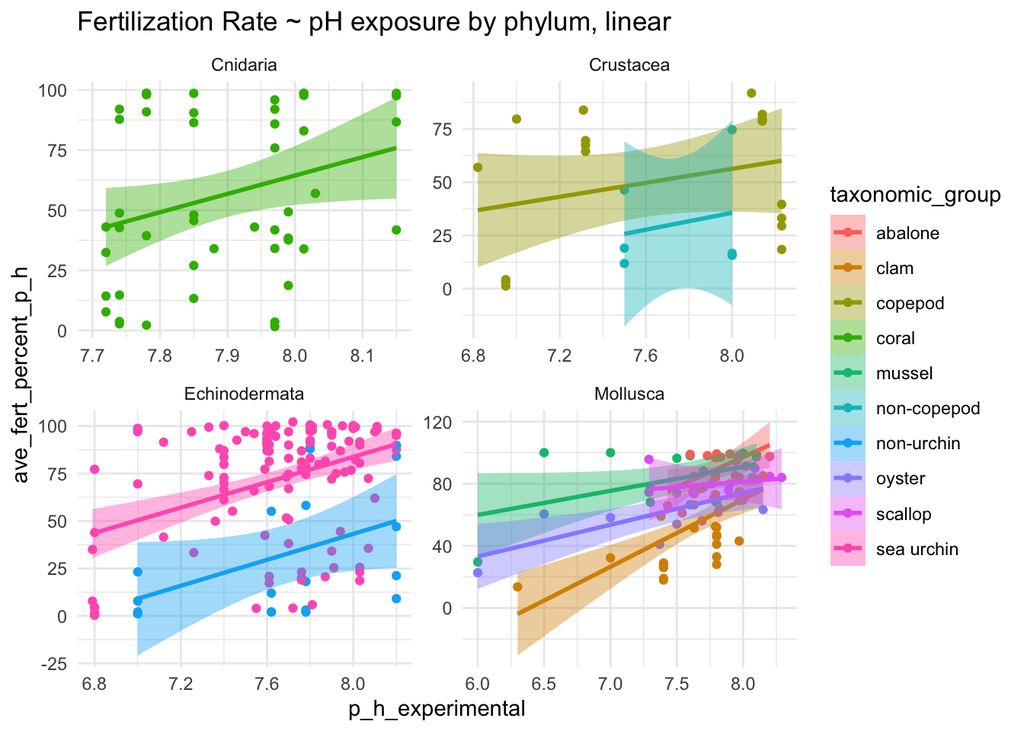

```r
#ggplotly(
data.fert %>%
ggplot(mapping=aes(x=p_h_experimental, y=ave_fert_percent_p_h, group=taxonomic_group, col=taxonomic_group, text=`common_name`)) +
  geom_point(size=1.5, width=0.02) +
  facet_wrap(~phylum, scale="free") +
  geom_smooth(method="lm", se=TRUE, aes(fill=taxonomic_group)) +
  ggtitle("Fertilization Rate ~ pH exposure by phylum, linear") +
  theme_minimal()
```

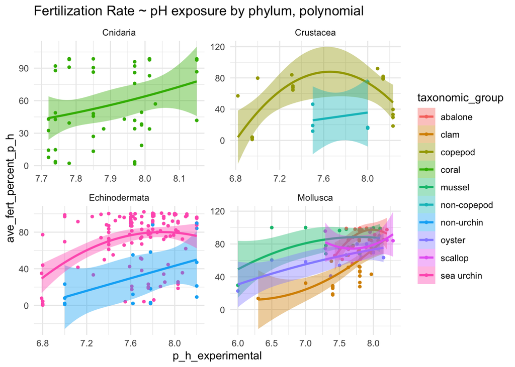

```r
#)

#ggplotly(
data.fert %>%
ggplot(mapping=aes(x=p_h_experimental, y=ave_fert_percent_p_h, group=taxonomic_group, col=taxonomic_group, text=`common_name`)) +
  geom_point(size=1, width=0.02) +
  facet_wrap(~phylum, scale="free") +
  geom_smooth(method="lm", se=TRUE, formula=y ~ poly(x, 2, raw=TRUE), aes(fill=taxonomic_group)) +
  ggtitle("Fertilization Rate ~ pH exposure by phylum, polynomial") +
  theme_minimal()
```

```r
#)
```

### Convert all error values to separate SE & SD columns

#### 95% Confidence Interval

Upper 95% CI = Mean + 1.96*SE; I recorded the difference between the upper 95%CI and the mean (Upper 95%CI - Mean). To convert I will use:  
**SE = (Upper 95%CI - Mean) / 1.96**

**SD = ((Upper 95%CI - Mean) / 1.96) * sqrt(n)**

#### Standard Deviation

SE= SD/sqrt(n); where n=sample size. To convert I will use that equation (since I recorded sample size, i.e. number of trials at each pH)

SD = SE*sqrt(n)

#### Cases where I do not know the type of error statistic reported

I will use that statistic as-is (no conversion), thereby assuming it is SE.

```r
data.fert <- data.fert %>%
  mutate(SE =  case_when(error_statistic == "SD" ~ error_percent_p_h/sqrt(number_trials_p_h),
         error_statistic == "95% CI" ~ error_percent_p_h/1.96,
         is.na(error_statistic) ~ error_percent_p_h,
         error_statistic == "SE" ~ error_percent_p_h))

data.fert <- data.fert %>%
  mutate(SD =  case_when(error_statistic == "SE" ~ error_percent_p_h*sqrt(number_trials_p_h),
         error_statistic == "95% CI" ~ (error_percent_p_h/1.96)*sqrt(number_trials_p_h),
         is.na(error_statistic) ~ error_percent_p_h,
         error_statistic == "SD" ~ error_percent_p_h))

data.fert %>% View()
```

### Calculate pH experimental - pH control

```r
data.fert <- data.fert %>%
  mutate(pH_delta = p_h_control-p_h_experimental)
```

### Convert % fertilization data to proportion fertilized, and replace any values >1 (aka 100% fertilized) with 1

```r
data.fert <- data.fert %>%
  mutate(ave_fert_proport = case_when(ave_fert_percent_p_h <= 100 ~ ave_fert_percent_p_h/100,
                                      ave_fert_percent_p_h > 100 ~ 1))
```

### Transform proportion fertilized data to remove 1’s

Transormation equation source: https://cran.r-project.org/web/packages/betareg/vignettes/betareg.pdf, " … if y also assumes the extremes 0 and 1, a useful transformation in practice is (y · (n − 1) + 0.5)/n where n is the sample size (Smithson and Verkuilen 2006)."

#### HOWEVER

issue is that a few studies only had 1 trial per pH, so the transformation results in NA values

```r
 # data.fert$ave_fert_proport.t <- data.fert$ave_fert_proport*((data.fert$number_trials_p_h-1) + 0.5) / data.fert$number_trials_p_h
```

#### Instead, I simply subtracted 0.001 from all data (but not sure if I will use that transformed data)

```r
data.fert$ave_fert_proport.t <- data.fert$ave_fert_proport - 0.001
```

### Inspect data

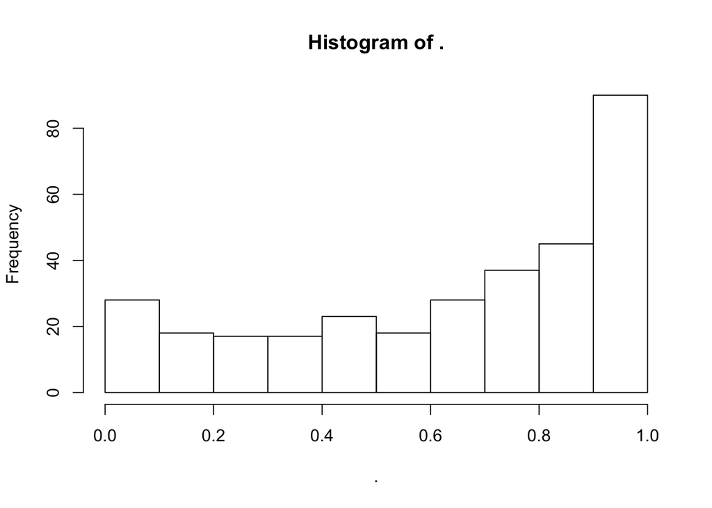

```r
data.fert$ave_fert_proport.t %>% hist()
```

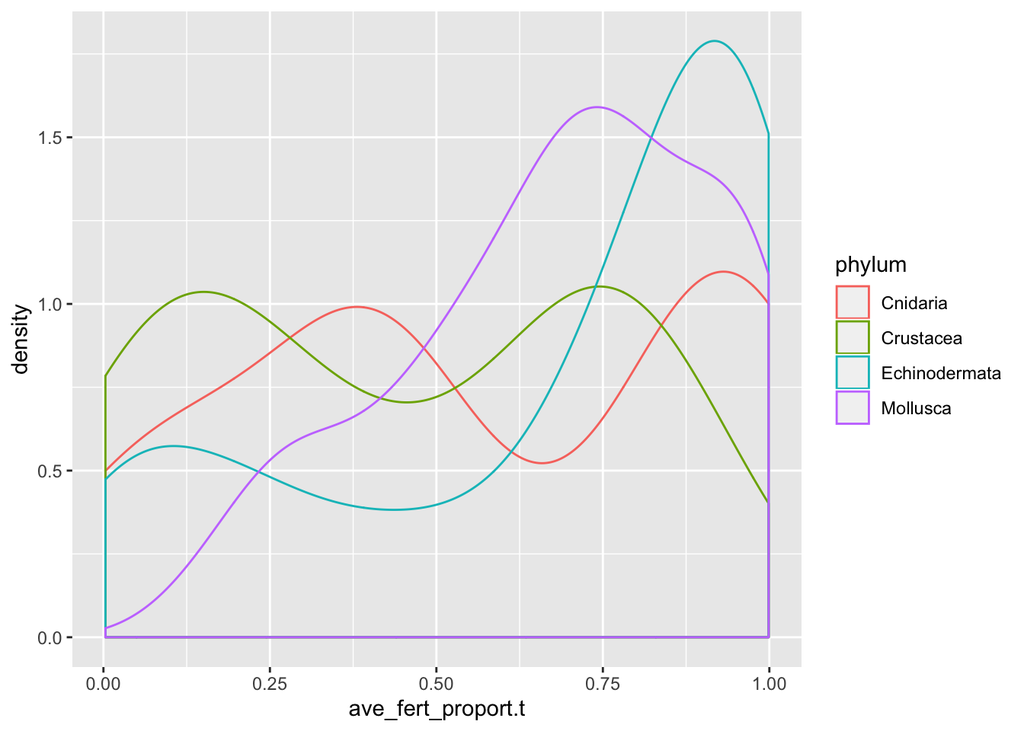

```r
ggplot(data.fert, aes(group=phylum, col=phylum)) + geom_density(aes(ave_fert_proport.t))
```

```r
# How many studies per ~phylum?
data.fert %>%
  select(phylum, study) %>%
  distinct(phylum, study) %>%
  group_by(phylum) %>% count()
```

```
## # A tibble: 4 x 2
## # Groups:   phylum [4]
##   phylum            n
##   <fct>         <int>
## 1 Cnidaria          4
## 2 Crustacea         5
## 3 Echinodermata    12
## 4 Mollusca         18
```

```r
# How many studies per taxonomic group?
data.fert %>%
  select(phylum, study, taxonomic_group) %>%
  distinct(phylum, study, taxonomic_group) %>%
  group_by(taxonomic_group) %>% count()
```

```
## # A tibble: 10 x 2
## # Groups:   taxonomic_group [10]
##    taxonomic_group     n
##    <fct>           <int>
##  1 abalone             2
##  2 clam                5
##  3 copepod             3
##  4 coral               4
##  5 mussel              4
##  6 non-copepod         2
##  7 non-urchin          2
##  8 oyster              5
##  9 scallop             3
## 10 sea urchin         11
```

### Calculate weights for models

#### NOTE: not working due to missing data.

```r
weights <- metafor::escalc(measure='MN',
                mi=data.fert$ave_fert_percent_p_h,
                sdi = data.fert$SD,
                ni=data.fert$number_trials_p_h, options(na.action="na.pass"))
```